# **Charakterystyka algorytmu klasyfikacji na podstawie drzew decyzyjnych**

Ewelina Kamrowska

### **Wstęp**

Drzewa decyzyjne (ang. *decision trees*) stanowią najczęściej stosowaną grupę algorytmów klasyfikacyjnych. Drzewo jest klasyfikatorem, który ma postać skierowanego grafu acyklicznego i spójnego o strukturze drzewa. Drzewo składa się z korzenia oraz gałęzi prowadzących z korzenia do kolejnych węzłów. Będziemy rozważać tylko drzewa binarne, tzn. z każdego wierzchołka wychodzą dwie krawędzie lub zero krawędzi dla liści.

W przypadku drzew decyzyjnych wierzchołki nazywamy węzłami, a krawędzie gałęziami. Węzeł, z którego wychodzą gałęzie do innych węzłów nazywamy rodzicem tych węzłów, a węzły, do których prowadzą te gałęzie nazywamy dziećmi. Węzeł, który nie ma dzieci nazywamy liściem. Do każdego liścia od korzenia prowadzi tylko jednak droga.

W korzeniu drzewa skupiona jest cała próba ucząca i następnie każde obiekty tej próby przesuwane są wzdłuż gałęzi z góry do dołu. W każdym węźle, który nie jest liściem jest dokonywany podział elementów próby uczącej docierających do tego węzła na podgrupy. Kryterium podziału dokonywanego w danym węźle jest takie samo dla wszystkich elementów, które znajdują się w tym węźle. Każda krawędź wychodząca z wierzchołka wewnętrznego reprezentuje wartość atrybuty podziałowego lub wynik testu związanego z danym wierzchołkiem wewnętrznym.

Z każdym liściem drzewa związana jest etykieta klasy atrybutu decyzyjnego. Wybierana jest ta klasa atrybutu decyzyjnego, do którego należy większość elementów próby uczącej, które trafiły do danego liścia.

### **Reguły podziału drzewa decyzyjnego**

Tworząc dowolny algorytm konstrukcji drzew decyzyjnych należy:

- określić optymalną wielkość drzewa (to czy dany węzeł ma być węzłem końcowym, czy ma podlegać dalszemu podziałowi). Należy określić warunek stopu, np. konstrukcja drzewa zostaje zakończona, jeżeli liczba obserwacji partycji związanej z wierzchołkiem jest mniejsza od pewnego zadanego progu.
- wybrać metodę optymalnego podziału węzłów, czyli zdefiniować metodę wyboru punktu podziału zbioru uczącego, tzn. należy określić metody wyboru atrybutu podziałowego. Podział w danym węźle odbywa się na podstawie tylko tych wektorów obserwacji podpróby uczącej, które znalazły się w tym węźle i polega na najlepszym w zadanym sensie rozdzieleniu podpróby na dwie części.

Różnorodność jest opisana rozkładem klas w podpróbie, np. g = 2 (dwie klasy), w węźle 80 elementów z pierwszej klasy i 20 elementów z drugiej klasy, to mamy rozkład 0.8 i 0.2. Zatem podział powinien być tak wybierany, aby różnorodność otrzymanych części docierających do węzła była jak najmniejsza. Istotne w konstrukcji drzewa jest zatem podanie stosowanej miary różnorodności klas w węźle.

Miary różnorodności klas w węźle:

- ułamek błędnych klasyfikacji,
- miara indeksu Gini,
- mira entropii.

Miary te bazują na ułamkach obserwacji w danym węźle, uznając je za przybliżone prawdopodobień- stwa pojawienia się w tym węźle obserwacji z danej klasy.

($X_{i}$ , $Y_{i}$) — próba ucząca, $i = 1, 2, . . . , n$,

$X_{i}$ — $m$–wymiarowy wektor atrybutów dla $i$–tej jednostki, $X_{i} = (X_{i1} , X_{i2} , . . . , X_{im})$,

$Y_{i}$ — atrybut decyzyjny,

$n$ — liczba obserwacji uczących.

Frakcja elementów z klasy $k$ w węźle $m$ wynosi:

$$p_{mk} = \frac{1}{n_{m}}\sum_{x \in R_{m}} \frac{n_{mk}}{n_{m}},$$

gdzie:

- $n_{m}$ - liczba obserwacji uczących w węźle $m$,
- $n_{mk}$ - liczba obserwacji uczących w węźle $m$ z $k$-tej klasy.

Rozsądna miara różnorodności klas w węźle powinna przyjmować zero, gdy wszystkie obserwacje w węźle należą do tej samej klasy oraz wartość maksymalną, gdy rozkład przynależności do klas jest jednostajny.

Dla każdego węzła $m$ określamy pewną miarę różnorodności (czyli niejednorodności) elementów w tym węźle ($T$ - drzewo):

- ułamek błędnej klasyfikacji w węźle $m$

$$Q_m(T) = 1 - p_{mk}(m),$$

- indeks Giniego

$$Q_m(T) = 1 - \sum_{k = 1} p_{mk}^2,$$

- entropia (miara zysku informacji)

$$Q_m(T) = \sum_{k = 1} p_{mk} \log_2p_{mk}.$$

Wzrost wartości indeksów powoduje wzrost niejednorodności rozkładu zmiennej decyzyjnej w węźle m. Stąd wybieramy tę klasę, która charakteryzuje się najmniejszym indeksem, czyli wybierany jest taki podział, który daje maksymalną redukcje niejednorodności indeksu przynależności do klasy w węźle.

### **Przykład budowy drzewa decyzyjnego w środowisku R**

##### **Przygotowanie danych**

Przygotowany do analizy zbiór danych składa się z pomiarów właściwości geometrycznych ziarniaków należących do trzech różnych odmian pszenicy, kolejno: *Kamy*, *Rosy* i *Kanady*. Zbiór danych przechowuje zmienne, które opisują właściwości ziaren takie jak: powierzchnia (*area*), obwód (*perimeter*), spójność (*compactness*), długość (*length*) i szerokość ziarna (*width*), współczynnik asymetrii (*asymmetry*) oraz długość bruzdy ziarna (*groove*). Ostatnia kolumna zawiera informację o przynależności obserwacji do gatunku ziarna (*type*). Dane nie zawierają braków. Wszystkie zmienne są typu liczbowego (*numeric*), natomiast zmienna określająca gatunek ziarna jest typu *factor*.

Dane pochodzą ze strony: https://archive.ics.uci.edu/ml/datasets/seeds#.

| area | perimeter | compactness | length | width | asymmetry | groove | type |
| --- | --- | --- | --- | --- | --- | --- | --- |
| 15.26 | 14.84 | 0.8710 | 5.763 | 3.312 | 2.2210 | 5.220 | 1 |
| 14.88 | 14.57 | 0.8811 | 5.554 | 3.333 | 1.0180 | 4.956 | 1 |
| 14.29 | 14.09 | 0.9050 | 5.291 | 3.337 | 2.6990 | 4.825 | 1 |
| 13.84 | 13.94 | 0.8955 | 5.324 | 3.379 | 2.2590 | 4.805 | 1 |
| 16.14 | 14.99 | 0.9034 | 5.658 | 3.562 | 1.3550 | 5.175 | 1 |
| 14.38 | 14.21 | 0.8951 | 5.386 | 3.312 | 2.4620 | 4.956 | 1 |
| 14.69 | 14.49 | 0.8799 | 5.563 | 3.259 | 3.5860 | 5.219 | 1 |
| 16.63 | 15.46 | 0.8747 | 6.053 | 3.465 | 2.0400 | 5.877 | 1 |
| 16.44 | 15.25 | 0.8880 | 5.884 | 3.505 | 1.9690 | 5.533 | 1 |
| 15.26 | 14.85 | 0.8696 | 5.714 | 3.242 | 4.5430 | 5.314 | 1 |
| 14.03 | 14.16 | 0.8796 | 5.438 | 3.201 | 1.7170 | 5.001 | 1 |
| 13.89 | 14.02 | 0.8880 | 5.439 | 3.199 | 3.9860 | 4.738 | 1 |
| 13.78 | 14.06 | 0.8759 | 5.479 | 3.156 | 3.1360 | 4.872 | 1 |
| 13.74 | 14.05 | 0.8744 | 5.482 | 3.114 | 2.9320 | 4.825 | 1 |
| 14.59 | 14.28 | 0.8993 | 5.351 | 3.333 | 4.1850 | 4.781 | 1 |
| 13.99 | 13.83 | 0.9183 | 5.119 | 3.383 | 5.2340 | 4.781 | 1 |
| 15.69 | 14.75 | 0.9058 | 5.527 | 3.514 | 1.5990 | 5.046 | 1 |
| 14.70 | 14.21 | 0.9153 | 5.205 | 3.466 | 1.7670 | 4.649 | 1 |
| 12.72 | 13.57 | 0.8686 | 5.226 | 3.049 | 4.1020 | 4.914 | 1 |
| 14.16 | 14.40 | 0.8584 | 5.658 | 3.129 | 3.0720 | 5.176 | 1 |
| 14.11 | 14.26 | 0.8722 | 5.520 | 3.168 | 2.6880 | 5.219 | 1 |
| 15.88 | 14.90 | 0.8988 | 5.618 | 3.507 | 0.7651 | 5.091 | 1 |
| 12.08 | 13.23 | 0.8664 | 5.099 | 2.936 | 1.4150 | 4.961 | 1 |
| 15.01 | 14.76 | 0.8657 | 5.789 | 3.245 | 1.7910 | 5.001 | 1 |
| 16.19 | 15.16 | 0.8849 | 5.833 | 3.421 | 0.9030 | 5.307 | 1 |
| 13.02 | 13.76 | 0.8641 | 5.395 | 3.026 | 3.3730 | 4.825 | 1 |
| 12.74 | 13.67 | 0.8564 | 5.395 | 2.956 | 2.5040 | 4.869 | 1 |
| 14.11 | 14.18 | 0.8820 | 5.541 | 3.221 | 2.7540 | 5.038 | 1 |
| 13.45 | 14.02 | 0.8604 | 5.516 | 3.065 | 3.5310 | 5.097 | 1 |
| 13.16 | 13.82 | 0.8662 | 5.454 | 2.975 | 0.8551 | 5.056 | 1 |
| 15.49 | 14.94 | 0.8724 | 5.757 | 3.371 | 3.4120 | 5.228 | 1 |
| 14.09 | 14.41 | 0.8529 | 5.717 | 3.186 | 3.9200 | 5.299 | 1 |
| 13.94 | 14.17 | 0.8728 | 5.585 | 3.150 | 2.1240 | 5.012 | 1 |
| 15.05 | 14.68 | 0.8779 | 5.712 | 3.328 | 2.1290 | 5.360 | 1 |
| 16.20 | 15.27 | 0.8734 | 5.826 | 3.464 | 2.8230 | 5.527 | 1 |
| 17.08 | 15.38 | 0.9079 | 5.832 | 3.683 | 2.9560 | 5.484 | 1 |
| 14.80 | 14.52 | 0.8823 | 5.656 | 3.288 | 3.1120 | 5.309 | 1 |
| 14.28 | 14.17 | 0.8944 | 5.397 | 3.298 | 6.6850 | 5.001 | 1 |
| 13.54 | 13.85 | 0.8871 | 5.348 | 3.156 | 2.5870 | 5.178 | 1 |
| 13.50 | 13.85 | 0.8852 | 5.351 | 3.158 | 2.2490 | 5.176 | 1 |
| 13.16 | 13.55 | 0.9009 | 5.138 | 3.201 | 2.4610 | 4.783 | 1 |
| 15.50 | 14.86 | 0.8820 | 5.877 | 3.396 | 4.7110 | 5.528 | 1 |
| 15.11 | 14.54 | 0.8986 | 5.579 | 3.462 | 3.1280 | 5.180 | 1 |
| 13.80 | 14.04 | 0.8794 | 5.376 | 3.155 | 1.5600 | 4.961 | 1 |
| 15.36 | 14.76 | 0.8861 | 5.701 | 3.393 | 1.3670 | 5.132 | 1 |
| 14.99 | 14.56 | 0.8883 | 5.570 | 3.377 | 2.9580 | 5.175 | 1 |
| 14.79 | 14.52 | 0.8819 | 5.545 | 3.291 | 2.7040 | 5.111 | 1 |
| 14.86 | 14.67 | 0.8676 | 5.678 | 3.258 | 2.1290 | 5.351 | 1 |
| 14.43 | 14.40 | 0.8751 | 5.585 | 3.272 | 3.9750 | 5.144 | 1 |
| 15.78 | 14.91 | 0.8923 | 5.674 | 3.434 | 5.5930 | 5.136 | 1 |
| 14.49 | 14.61 | 0.8538 | 5.715 | 3.113 | 4.1160 | 5.396 | 1 |
| 14.33 | 14.28 | 0.8831 | 5.504 | 3.199 | 3.3280 | 5.224 | 1 |
| 14.52 | 14.60 | 0.8557 | 5.741 | 3.113 | 1.4810 | 5.487 | 1 |
| 15.03 | 14.77 | 0.8658 | 5.702 | 3.212 | 1.9330 | 5.439 | 1 |
| 14.46 | 14.35 | 0.8818 | 5.388 | 3.377 | 2.8020 | 5.044 | 1 |
| 14.92 | 14.43 | 0.9006 | 5.384 | 3.412 | 1.1420 | 5.088 | 1 |
| 15.38 | 14.77 | 0.8857 | 5.662 | 3.419 | 1.9990 | 5.222 | 1 |
| 12.11 | 13.47 | 0.8392 | 5.159 | 3.032 | 1.5020 | 4.519 | 1 |
| 11.23 | 12.63 | 0.8840 | 4.902 | 2.879 | 2.2690 | 4.703 | 1 |
| 12.36 | 13.19 | 0.8923 | 5.076 | 3.042 | 3.2200 | 4.605 | 1 |

##### **Budowa i interpretacja drzewa decyzyjnego**

Za pomocą drzewa decyzyjnego przeprowadzimy klasyfikację ziaren ze względu na gatunek, do którego mają docelowo należeć. Przy budowie algorytmu klasyfikacji drzewa decyzyjnego wymagany jest podział danych, na zbiór testowy oraz uczący. W naszym zadaniu, $80\%$ obserwacji będzie stanowił zbiór uczący, natomiast $20\%$ zbiór testowy. Jako miarę różnorodności elementów w pojedyńczym węźle przyjęto *indeks Giniego*. Spróbujmy przedstawić drzewko graficznie, z przynależnością liczby ziaren do poszczególnych gatunków, określonych przez algorytm klasyfikacji.

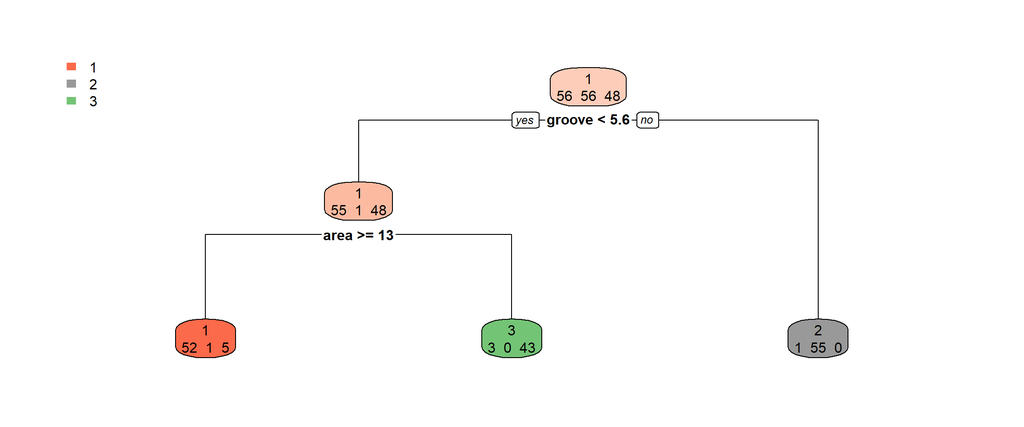

Zgodnie z dokonaną klasyfikacją powyższego schematu, drzewo można interpretować następująco:

- ziarna, których długość bruzdy ziarna osiąga co najmniej $5.6$ ($groove \geq 5.6$), zostają zaklasyfikowane w więkoszości do gatunku 2 (gatunek $Rosy$). Klasyfikacja ta jest widoczna w liściu oznaczonym kolorem szarym,
- ziarna, których długość bruzdy ziarna nie przekracza progu $5.6$ ($groove < 5.6$) oraz ich powierzchnia wynosi minimum 13 ($area \geq 13$), zostają automatycznie zaklasyfikowane do gatunku ziaren oznaczonych numerem 1 (gatunek $Kamy$). Klasyfikacja ta jest widoczna w liściu oznaczonym kolorem czerwonym,
- ziarna, których długość bruzdy ziarna nie przekracza progu $5.6$ ($groove < 5.6$) oraz ich powierzchnia wynosi mniej niż 13 ($area < 13$), zostają automatycznie zaklasyfikowane do gatunku ziaren oznaczonych numerem 3 (gatunek $Kanady$). Klasyfikacja ta jest widoczna w liściu oznaczonym kolorem zielonym.

Za pomocą odpowiednich funkcji w środowisku $R$ możemy również przedstawić drzewko decyzyjne z prawdopodobieństwami przynależności ziaren do poszczególnych gatunków, określonych przez algorytm klasyfikacji.

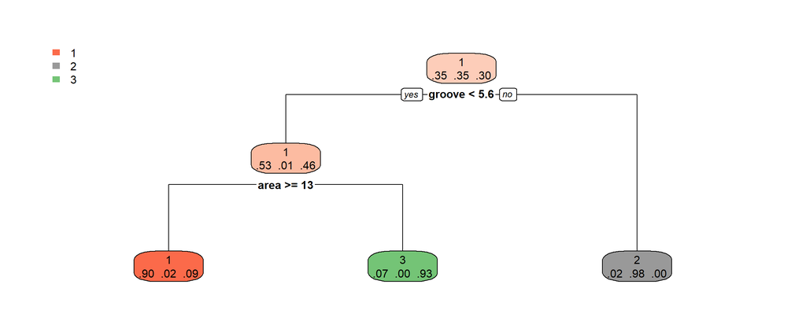

Jak wspomniano wyżej, ziarna, których długość bruzdy ziarna osiąga co najmniej $5.6$ (*groove* $\geq 5.6$), zostają zaklasyfikowane w więkoszości do gatunku 2 (gatunek *Rosy*, 55 obserwacji). Opierając się o budowę drugiego drzewa decyzyjnego z miarami prawdopodobieństw klasyfikacji, możemy powiedzieć, że obserwacje, których długość bruzdy ziarna osiąga co najmniej $5.6$ (*groove* $\geq 5.6$), zostaną zaklasyfikowane do gatunku 2 (gatunek *Rosy*) z $98 \%$ prawdopodobieństwem.

##### **Klasyfikacja obserwacji zbioru testowego na podstawie zbudowanego drzewa**

Na podstawie zbudowanego drzewa spróbujmy sklasyfikować obserwacje ze zbioru testowego do poszczególnych gatunków ziaren. Poniższe zestawienie zawiera oszacowane **prawdodobieństwa** przynależności kolejnych obserwacji (wiersze) ze zbioru testowego, do poszczególnych gatunków ziaren (kolumny) na podstawie zbudowanego drzewa decyzyjnego.

|  | 1 | 2 | 3 |
| --- | --- | --- | --- |
| 5 | 0.8965517 | 0.0172414 | 0.0862069 |
| 14 | 0.8965517 | 0.0172414 | 0.0862069 |
| 16 | 0.8965517 | 0.0172414 | 0.0862069 |
| 26 | 0.8965517 | 0.0172414 | 0.0862069 |
| 28 | 0.8965517 | 0.0172414 | 0.0862069 |
| 29 | 0.8965517 | 0.0172414 | 0.0862069 |
| 39 | 0.8965517 | 0.0172414 | 0.0862069 |
| 40 | 0.8965517 | 0.0172414 | 0.0862069 |
| 60 | 0.0652174 | 0.0000000 | 0.9347826 |
| 61 | 0.8965517 | 0.0172414 | 0.0862069 |
| 72 | 0.0178571 | 0.9821429 | 0.0000000 |
| 81 | 0.0178571 | 0.9821429 | 0.0000000 |
| 86 | 0.0178571 | 0.9821429 | 0.0000000 |
| 90 | 0.0178571 | 0.9821429 | 0.0000000 |
| 92 | 0.0178571 | 0.9821429 | 0.0000000 |
| 113 | 0.0178571 | 0.9821429 | 0.0000000 |
| 116 | 0.0178571 | 0.9821429 | 0.0000000 |
| 117 | 0.0178571 | 0.9821429 | 0.0000000 |
| 122 | 0.0178571 | 0.9821429 | 0.0000000 |
| 123 | 0.0178571 | 0.9821429 | 0.0000000 |
| 124 | 0.0178571 | 0.9821429 | 0.0000000 |
| 131 | 0.0178571 | 0.9821429 | 0.0000000 |
| 135 | 0.8965517 | 0.0172414 | 0.0862069 |
| 137 | 0.8965517 | 0.0172414 | 0.0862069 |
| 140 | 0.0652174 | 0.0000000 | 0.9347826 |
| 142 | 0.0652174 | 0.0000000 | 0.9347826 |
| 149 | 0.0652174 | 0.0000000 | 0.9347826 |
| 154 | 0.0652174 | 0.0000000 | 0.9347826 |
| 156 | 0.0652174 | 0.0000000 | 0.9347826 |
| 158 | 0.0652174 | 0.0000000 | 0.9347826 |
| 169 | 0.0652174 | 0.0000000 | 0.9347826 |
| 185 | 0.0652174 | 0.0000000 | 0.9347826 |
| 187 | 0.8965517 | 0.0172414 | 0.0862069 |
| 192 | 0.0652174 | 0.0000000 | 0.9347826 |
| 194 | 0.0652174 | 0.0000000 | 0.9347826 |
| 195 | 0.0652174 | 0.0000000 | 0.9347826 |
| 196 | 0.0652174 | 0.0000000 | 0.9347826 |
| 197 | 0.8965517 | 0.0172414 | 0.0862069 |
| 199 | 0.0652174 | 0.0000000 | 0.9347826 |

##### **Macierz pomyłek klasyfikatora**

Przy użyciu funkcji *confusionMatrix*, zastosowanej w środowisku *RStudio*, możemy również uzyskać tzw. **macierz pomyłek** klasyfikacji ziaren zbioru testowego. Wiersze macierzy oznaczają kolejno, ile obserwacji przydzielił klasyfikator do poszczególnych gatunków ziaren, natomiast kolumny - ile faktycznie obserwacji poszczególnych gatunków znajdowało się w zbiorze testowym. Przykładowo, na podstawie zbudowanego drzewa decyzyjnego klasyfikator przydzielił 9 obserwacji do gatunku oznaczonego numerem 1 (i pokrywa się to ze stanem faktycznym) ale również przydzielił błędnie 1 obserwację do gatunku oznaczonego numerem 3, gdzie faktycznie obserwacja ta, powinna zostać sklasyfikowana do gatunku oznaczego numerem 1. Macierz pomyłek dla naszego zadania ma postać:

```
##           Reference
## Prediction  1  2  3
##          1  9  0  4
##          2  0 12  0
##          3  1  0 13
```

##### **Ocena jakości modelu klasyfikacyjnego**

Na podstawie zbudowanej macierzy pomyłek, w łatwy sposób możemy policzyć tzw. **dokładność klasyfikacji (ACC)**. Miara ta, określa jaką część wszystkich obserwacji, stanowią obserwacje poprawie sklasyfikowane. W naszym zadaniu będzie to stosunek sumy elementów leżących na głównej przekątnej macierzy, do sumy wszystkich elementów zawartych w macierzy pomyłek. Dokładność klasyfikacji wynosi w naszym zadaniu $ACC \approx 0.87$. Liczba ta wyraża więc stosunek liczby prawidłowo dopasowanych ziaren do swojego gatunku, do wszystkich obserwacji w zbiorze testowym.

Przez **błąd klasyfikacji (ERR)** możemy rozumieć stosunek sumy elementów leżących poza główną przekątną (obserwacji błędnie sklasyfikowanych), do sumy wszystich elementów zawartych w macierzy pomyłek. Błąd klasyfikacji dla zbioru testowego wynosi w zadaniu $ERR \approx 0.13$.

Do popularnych wskaźników oceny jakości zbioru testowego drzewa należą również takie parametry jak **czułość** (ang. *sensitivity*), **specyficzność** (ang. *specificity*) oraz precyzja (ang. *precision*). Poniżej przedstawiono wartości tych parametrów dla poszczególnych klas, które reprezentują gatunki ziaren. Parametr *sensitivity* wskazuje, w jakim procencie klasa faktycznie pozytywna została pokryta przewidywaniem pozytywnym. Dokładniej oznacza to, w ilu przypadkach klasyfikator poprawnie rozpoznaje obserwacje. Przykładowo wartość parametru czułości dla klasy 2 (gatunek ziarna oznaczony numerem 2) wynosi 1, co oznacza, że klasyfikator poprawnie sklasyfikował wszystkie obserwacje (ziarna) należące właśnie do tego gatunku. Parametr *specificity* wskazuje, w jakim procencie klasa faktycznie negatywna, została pokryta przewidywaniem negatywnym, natomiast parametr *precision* określa, w ilu przypadkach klasyfikator się nie myli.

```
##          Sensitivity Specificity Pos Pred Value Neg Pred Value Precision
## Class: 1   0.9000000   0.8620690      0.6923077      0.9615385 0.6923077
## Class: 2   1.0000000   1.0000000      1.0000000      1.0000000 1.0000000
## Class: 3   0.7647059   0.9545455      0.9285714      0.8400000 0.9285714
##             Recall        F1 Prevalence Detection Rate
## Class: 1 0.9000000 0.7826087  0.2564103      0.2307692
## Class: 2 1.0000000 1.0000000  0.3076923      0.3076923
## Class: 3 0.7647059 0.8387097  0.4358974      0.3333333
##          Detection Prevalence Balanced Accuracy
## Class: 1            0.3333333         0.8810345
## Class: 2            0.3076923         1.0000000
## Class: 3            0.3589744         0.8596257
```

### *Podsumowanie*

Drzewo decyzyjne to nic innego jak graficzny sposób wspierania procesu decyzyjnego. Drzewo stosowane jest w teorii decyzji i ma sporo zastosowań. Może zarówno rozwiązać problem decyzyjny, jak i stworzyć plan. Metoda drzew decyzyjnych sprawdza się przede wszystkim, kiedy mamy problemy decyzyjne z wieloma rozgałęziającymi się wariantami. Drzewa znalazły zastosowanie w takich dziedzinach jak botanika i medycyna. Coraz częściej sięga się do nich także w ekonomii, gdyż są w stanie ułatwiać i usprawniać komputerowe wspomaganie procesu podejmowania decyzji. Technika drzew decyzyjnych, czy też klasyfikacyjnych, jak niektórzy je nazywają, w dużej mierze pozwala na wyznaczenie zasad decyzyjnych opisujących reguły przypisywania obiektów do wyróżnionych klas.